# COMP41680 ASSIGNMENT 2: Text Scraping & Clustering

This project is divided into two parts:

1. Text Scrapping from the source http://mlg.ucd.ie/modules/COMP41680/news/index.html
2. Pre-Processing and clustering the data scrapped

The first part i.e text scrapping is done using python script **'PrashantGarg16201447_TextScrapping.py'** The final output of this script file is the csv file **'ARTICLES.CSV'** which contains the information of the month, headline and complete article body for the News item.

The month denotes the month in which the news was published, the headline is the news headline for the article and the Article column contains the complete body of the News item saved as plain text

Note 1 : Please download and install the packages specified if not insalled, before executing the code :  
[ SKLEARN ], [ NLTK ] , [ SCIKIT-LEARN ]  
Note 2 : It is recommended that each cell is run incremental fashion one by one  
Note 3 : Run the script file before running this iPython notebook

```python
#
# Created By:   P R A S H A N T   G A R  G  |  STUDENT ID : 16201447
# Created Date: 05-April-2017
# Copyright:    University College Dublin
# Subject       Data Science in Python
#

# Version:                  00.00.00.01

# Modification history:
# None
```

#### Import of Libraries

```python
import pandas as pd # data manipulation, processing and analysis
import numpy as np # Numerical computing

#Imports in sklearn library - clustering, dimensionality reduction
from sklearn.feature_extraction.text import CountVectorizer
from sklearn.feature_extraction import text
from sklearn.feature_extraction.text import TfidfVectorizer #TF_IDF
from sklearn.metrics.pairwise import cosine_similarity #Cosine_Similarity
from sklearn.cluster import KMeans #K-Mean Cluster
from sklearn.externals import joblib #Clustering Labels

#Imports in nltk - Natural Language processing
import nltk
from nltk.tokenize import word_tokenize # Tokenization
from nltk.corpus import stopwords # Stop Word Filtering
from nltk.stem import WordNetLemmatizer #Lemmatisation
from nltk.corpus import wordnet as wn #for fetching word type


#Imports in matplotlib - Plotting of Graphs
%matplotlib inline
import matplotlib.pyplot as plt

#To perform operator functions on items
import operator

#For Regular Expessions
import re
```

#### Important variables

```python
vectorizer = CountVectorizer() #Creates reference to CountVectorizer
stop_words1 = set(stopwords.words("english")) #Stores the Stop-word set from NLTK
stop_words2 = text.ENGLISH_STOP_WORDS #Stores the Stop-word set from SKLEARN
lemmatizer = WordNetLemmatizer() #creates reference to WordNetLemmatizer
tokenize = vectorizer.build_tokenizer() #cretes reference to build_tokenizer
docs_info = None #variable to store unicode values for column article in the CSV
```

### STEP 1 : Loading Text Corpus

```python
#
# Method Name: [convertToDocuments]
# This method converts the data of Article column from the CSV to the
# raw_documents forms
# @return raw_documents
#
def convertToDocuments(articlesArray):
    try:
        raw_documents = []
        for article in articlesArray:
            #inserting documents in lower text format into raw_document list
            raw_documents.append(str(article).lower())
        return raw_documents
    except Exception as e:
        print("Error in Method convertToDocuments : ",e)
```

```python
try:
    #Reading the CSV in latin_1 encoded format
    articlesDataFrame = pd.read_csv("ARTICLES.csv", encoding='latin_1')

    #Converting the dataframe to numpy array to construct document list
    articlesArray = np.array(articlesDataFrame['Article'])

    #documents list is created using this
    documents = convertToDocuments(articlesArray)
    docs_info = articlesDataFrame['Article'].values.astype('U') #variable to store unicode values for column article in the CSV
except:
    print("Some error while reading the file or loading the documents")
```

#### Characteristics of the Corpus Loaded

There are total **1131** number of news items scrapped with maximum of **100** news published in the month of **January** and minimum **90** news published in the month **December**

```python
print("The Total number of News Articles present are " , len(documents))
articlesInMonth = articlesDataFrame.groupby('Month')
count = articlesInMonth['Article'].count()
print("\n",count.sort_values(ascending=False))
```

```
The Total number of News Articles present are  1131

 Month
January      100
November      97
June          97
April         96
July          95
September     94
May           94
October       93
August        92
March         91
February      91
December      90
Name: Article, dtype: int64
```

### STEP 2 : Pre-processing the Documents to create Tokens

#### 1. Creating Stop Words set

```python
#StopWords
#
# Method Name: [getStopWords]
# This method contructs the set of StopWords (custom and pre-made)
# @return set of stopwords
#
def getStopWords():
    try:
        custom_stop_words = ['news','headline','said','cent','year','time','month','people'] #custom stop word list
        custom_stop_words.extend(stop_words1) #stop word list from NLTK
        custom_stop_words.extend(stop_words2) #stop word list from SKLEARN
        final_stopwords = set(custom_stop_words) #Final set of stop_words
        return final_stopwords
    except Exception as e:
        print("Error in getStopWords ," ,e)
```

#### 2. Applying Tokenization, lemmatisation, token length & Stop-word Filtering

```python
#
# Method Name: [preprocessCorpus]
# This method preprocesses the corpus - Applies Tokenization, Stop Word Filtering, Lemmatisation
# @return tokens after applying preprocessing
#
def preprocessCorpus(raw_document):

    try:
        tokens = []
        stopWords = getStopWords() #Fetching the stop word list
        for doc in raw_document:
            doc = str(doc)
            try:
                tokensExtracted = tokenize(doc)
                for tok in tokensExtracted:
                    #Lemmatizing
                    lemmedTok = lemmatizer.lemmatize(tok)
                    #if the token is not a regular expression and is a string, its length is more than 3 and is not in the list of stopwords
                    if re.search('[a-zA-Z]', lemmedTok) and len(lemmedTok)>3 and lemmedTok not in stopWords:
                        tokens.append(lemmedTok)
            except Exception as e:
                pass
        return tokens
    except Exception as e:
        print("Some error in preprocessCorpus method ",e)
```

```python
#
# Method Name: [preprocessCorpusVector]
# This method preprocessCorpusVector the corpus - Applies Tokenization, Stop Word Filtering, Lemmatisation
# @return tokens after applying preprocessing
#
def preprocessCorpusVector(raw_document):

    try:
        tokens = []
        stopWords = getStopWords() #Fetching the stop word list
        doc = str(raw_document)
        try:
            tokensExtracted = tokenize(doc)
            for tok in tokensExtracted:
                #Lemmatizing
                lemmedTok = lemmatizer.lemmatize(tok)
                #if the token is not a regular expression and is a string, its length is more than 3 and is not in the list of stopwords
                if re.search('[a-zA-Z]', lemmedTok) and len(lemmedTok)>3 and lemmedTok not in stopWords:
                    tokens.append(lemmedTok)
        except Exception as e:
            pass
        return tokens
    except Exception as e:
        print("Some error in preprocessCorpus method ",e)
```

Pre-processing the documents we are having in the documents list

### STEP 3 : Summarising the Corpus

In this section, the description of the corpus will be given

#### 1.Total Token in Corpus after Preprocessing

```python
#Calling the pre-processing method to fetch tokens list
%time tokens_list  = preprocessCorpus(documents)
print("Total Tokens after Preprocessing = ", len(tokens_list))
```

```
Wall time: 3.45 s
Total Tokens after Preprocessing =  220291
```

#### 2. Unique Tokens in the corpus

```python
#
# Method Name: [fetchUniqueTokens]
# This method fetches unique tokens from the list of total token and returns
# @return unique tokens list
#
uniqToks = {}
def fetchUniqueTokens(tokens_list):
    try:
        for token in tokens_list:
            if token in uniqToks:
                uniqToks[token] += 1
            else:
                uniqToks[token] = 1
    except Exception as e:
        print("Error while fecthing the unique tokens")
    return uniqToks
```

```python
#Calling the fetchUniqueTokens method to fetch Unique-Tokens
unique_tokens_list  = fetchUniqueTokens(tokens_list)
print("%d unique terms are present in the corpus" % len(unique_tokens_list))
```

```
17425 unique terms are present in the corpus
```

#### 3. Major Features in the Corpus

```python
#
# Method Name: [majorFeatures]
# This method fetches 15 dominating features present in the corpus
# @return unique tokens list
#
def majorFeatures():
    try:
        ed_counts = sorted(counts.items(), key=operator.itemgetter(1), reverse=True)
        for i in range(15):
            term = sorted_counts[i][0]
            count = sorted_counts[i][1]
            print( "%s (count=%d)" % (term, count ))
    except Exception as e:
        print("Some error in majorFeatures method " , e)
```

```python
#Calling the majorFeatures to display the features most dominated in the corpus
majorFeatures()
```

```
Some error in majorFeatures method  name 'counts' is not defined
```

### STEP 4 : Constructing document term matrix and Further Summarising the corpus

```python
#Finding TF-IDF Matrix

# We need a vectorized parameter to construct this matrix
# The parameter max_df of 0.8 denotes that the term maximum be present in 80% documents..if it is more than
# that, then it is not considered.
# A min_df of 0.1 indicates that the token must be present in atleast 10% of documents
# As tokenizer the method preprocessCorpusVector method is used
# A bi-gram is also considered
tfidf_vectorizer = TfidfVectorizer(max_df=0.8,min_df=0.1, use_idf=True, tokenizer=preprocessCorpusVector, ngram_range=(1,2))
%time tfidf_matrix = tfidf_vectorizer.fit_transform(docs_info) #fit the vectorizer to synopses
print(tfidf_matrix.shape)
```

```
Wall time: 4.91 s
(1131, 206)
```

**(1131, 206) shows the document-term matrix which actually signifies that there 1131 documents which are represented using 206 terms**

```python
terms = tfidf_vectorizer.get_feature_names()
vocab = tfidf_vectorizer.vocabulary_
```

The vocab represents the dictionary with with the documents are represented, along with it contains the counts .ie. a count of that term being present in how many documents

```python
# totalvocab_tokenized = []
# for doc in documents:
#     allwords_tokenized = preprocessing(str(doc))
# totalvocab_tokenized.extend(allwords_tokenized)
```

```python
# vocab_frame = pd.DataFrame({'words': totalvocab_tokenized}, index = totalvocab_tokenized)
# print("there are " + str(vocab_frame.shape[0]) + " items in vocab_frame")
# vocab_frame.to_csv("vocab.csv")
```

### STEP 5 : Calculating the Distance between documents using Cosine Similarity

```python
distanceMatrix = 1 - cosine_similarity(tfidf_matrix)
```

The distance matrix holds the the ditance matrix, i.e how similar are the two documents based on the features extracted. This matrix will be useful while generating agglomerative clustering.

### Step 6 : CLUSTERING

This is the main excercise of this project. The aim is to cluster the documents into groups based on the similarity between them. For this particular poject I have used the example of K-Mean and Agglomerative clustering.

K-Mean is an example of partitional clustering algorithms and is based on finding the cluster centroid to partition the data into clusters whereas the Agglomerative algorithms start with each item assigned to its own cluster, and then apply a bottom-up strategy where, at each step, the most similar (least distant) pair of clusters are merged. We continue until we reach a specified number of clusters or until every item is in a single cluster. It uses distance for the evaluation. Here cosine distance is used to solve the purpose.

Note 4 : The assistance from **Document Clustering with Python [http://brandonrose.org/clustering]** is taken to plot these graphs

#### 1. Applying K-Means algorithm on the Document-Term Matrix)

```python
#Specifying the number of clusters
num_of_clusters = 4

#Initializing the KMEans
km = KMeans(n_clusters=num_of_clusters)

#Fitting the Document-Term matrix to the K-MEans
%time km.fit(tfidf_matrix)

#Storing label of the features in the clustes variable
clusters = km.labels_.tolist()
```

```
Wall time: 2.6 s
```

```python
#Dumping the Labels in a file and creating a dataframe
joblib.dump(km,  'doc_cluster.pkl') #Storing labels in a file
km = joblib.load('doc_cluster.pkl') # loading the labels from that file
clusters = km.labels_.tolist() #Storing label of the features in the clustes variable
news_info = {'documents': documents, 'cluster': clusters }
frame = pd.DataFrame(news_info, index = [clusters] , columns = ['documents','cluster'])
```

#### 2. Check how many documents are present in each clusters

```python
frame['cluster'].value_counts()
```

```
1    363
0    307
3    265
2    196
Name: cluster, dtype: int64
```

#### 3. Find the important features in the Evey cluster

```python
from __future__ import print_function
#sort cluster centers by proximity to centroid
order_centroids = km.cluster_centers_.argsort()[:, ::-1]
clusterAttributes = []

vectorizer = TfidfVectorizer(max_df=0.8,min_df=0.1, use_idf=True, tokenizer=preprocessCorpusVector, ngram_range=(1,2))
X2 = vectorizer.fit_transform(articlesDataFrame['Article'].values.astype('U'))
terms = vectorizer.get_feature_names()
true_k = 4
model = KMeans(n_clusters=true_k, init='k-means++', max_iter=100, n_init=1)
model.fit(X2)
print("Top terms per cluster:")
order_centroids = model.cluster_centers_.argsort()[:, ::-1]
for i in range(true_k):
    termNames = []
    print("Cluster %d:" % i, "\n" , )
    for ind in order_centroids[i, :10]:
        print(' %s' % terms[ind], end=" \n")
        termNames.append(terms[ind]);
    clusterAttributes.append(termNames)
    print()
```

```
Top terms per cluster:
Cluster 0:

 game
 player
 club
 goal
 united
 league
 team
 play
 football
 manager

Cluster 1:

 ireland
 bank
 irish
 economy
 rate
 government
 billion
 economic
 growth
 country

Cluster 2:

 technology
 user
 computer
 service
 firm
 company
 website
 information
 online
 million

Cluster 3:

 hospital
 health
 child
 patient
 service
 care
 report
 public
 department
 government
```

#### 4. Plotting the graph using MDS

```python
import os  # for os.path.basename
import matplotlib.pyplot as plt
import matplotlib as mpl
from sklearn.manifold import MDS
MDS()
mds = MDS(n_components=2, dissimilarity="precomputed", random_state=1)
pos = mds.fit_transform(distanceMatrix)  # shape (n_components, n_samples)
xs, ys = pos[:, 0], pos[:, 1]
cluster_colors = {0: '#1b9e77', 1: '#d95f02', 2: '#7570b3', 3: '#e7298a', 4: '#66a61e'}
cluster_names = {0: 'TECHNOLOGY NEWS',
                 1: 'SPORTS NEWS',
                 2: 'GOVERNMENT & HEALTH CARE NEWS',
                 3: 'IRELAND SPECIFIC NEWS'}
```

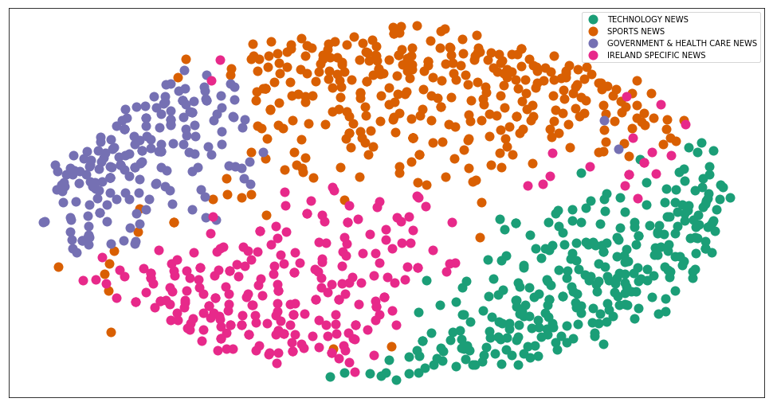

```python
#create data frame that has the result of the MDS plus the cluster numbers and titles
df = pd.DataFrame(dict(x=xs, y=ys, label=clusters))
#group by cluster
groups = df.groupby('label')
# set up plot
fig, ax = plt.subplots(figsize=(17, 9))
ax.margins(0.05)

#plotting for every group
for name, group in groups:
    ax.plot(group.x, group.y, marker='o', linestyle='', ms=12,
            label=cluster_names[name], color=cluster_colors[name],
            mec='none')
    ax.set_aspect('auto')
    ax.tick_params(\
        axis= 'x',          # changes apply to the x-axis
        which='both',      # both major and minor ticks are affected
        bottom='off',      # ticks along the bottom edge are off
        top='off',         # ticks along the top edge are off
        labelbottom='off')
    ax.tick_params(\
        axis= 'y',         # changes apply to the y-axis
        which='both',      # both major and minor ticks are affected
        left='off',      # ticks along the bottom edge are off
        top='off',         # ticks along the top edge are off
        labelleft='off')

ax.legend(numpoints=1)
for i in range(len(df)):
    ax.text(df.ix[i]['x'], df.ix[i]['y'],"", size=8)
plt.show() #show the plot
```

The different color represents different clusters

#### 5. Applying Agglomerative algorithm on the Document-Term Matrix) based on Distance

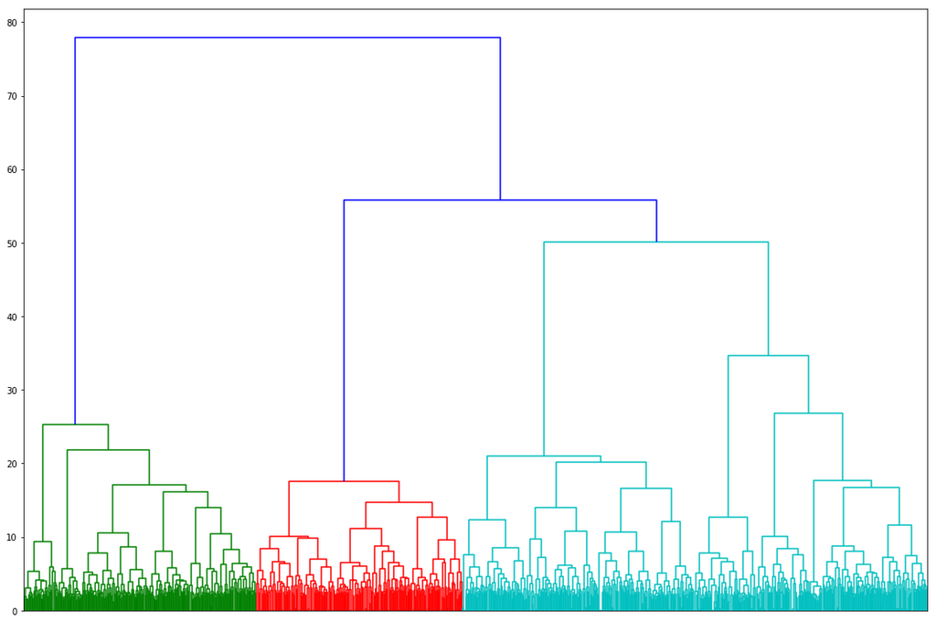

```python
from scipy.cluster.hierarchy import ward, dendrogram
distance_linkeage = ward(distanceMatrix) #define the linkage_matrix using ward clustering pre-computed distances
fig, ax = plt.subplots(figsize=(15, 10)) # set size
ax = dendrogram(distance_linkeage); #setting distance type
plt.tick_params(axis= 'x', which='both',bottom='off',top='off', labelbottom='off')
plt.tight_layout() #show plot with tight layout
```

Here we can decide and divide the cluster into sub-parts if reuired.